# Assignment 6

## Try to submit as an HTML file

Print your Emory code below

```python
print("2669234")
```

```
2669234
```

Import the "pandas" and "matplotlib.pyplot" libraries

```python
# Write your answer here:
import pandas as pd
import matplotlib.pyplot as plt
```

(a) Functions

- Read the dataset labelled features.csv.
- Create a `lambda` function that checks if displacement $>$ 200
- Create a new list that shows true if displacement $>$ 200 and false

if displacement $\leq$ 200.

- Count how many cars have displacement $> 200$.

To get full credit use either the apply or the map function  
(see Lectures 7 and 8)

```python
# Write your answer here:
dataset = pd.read_csv("data/features.csv")

check_displacement = lambda x: x>200
dataset["displacement_over_200"] = dataset["displacement"].apply(check_displacement)

print(dataset["displacement_over_200"].sum())
```

```
158
```

(b) Subsetting Data

- Read the dataset labelled features.csv.
- Define a global variable called `threshold` that takes the

value 2588

- Subset the data to get one dataset with weight $>$ threshold and

another with weight $\le$ 2588. Use the `.query()` function.

- Compute the mean acceleration for each of these datasets.

Note: Review how to define a gloabl variable inside `.query()`

```python
# Write your answer here:
dataset = pd.read_csv("data/features.csv")

threshold = 2588

weight_over = dataset.query("weight > @threshold")
weight_under = dataset.query("weight <= @threshold")

print(weight_over["acceleration"].mean())
print(weight_under["acceleration"].mean())
```

```
14.972457627118644
16.435802469135798
```

(c) Use sorting + ".iloc[]"

- Read the "fifa23_players_basic.csv" dataset
- Use ".sort_values()" to order the "Age" column

from youngest to oldest

- Get a subset with the 5 youngest players

```python
# Write your answer here:
dataset = pd.read_csv("data/fifa23_players_basic.csv")

dataset_sorted = dataset.sort_values(by = "Age", ascending = True)
dataset_sorted.iloc[0:5, :]
```

|  | Known As | Full Name | Overall | Potential | Value(in Euro) | Positions Played | Best Position | Nationality | Image Link | Age | ... | Preferred Foot | Weak Foot Rating | Skill Moves | International Reputation | National Team Name | National Team Image Link | National Team Position | National Team Jersey Number | Attacking Work Rate | Defensive Work Rate |
| --- | --- | --- | --- | --- | --- | --- | --- | --- | --- | --- | --- | --- | --- | --- | --- | --- | --- | --- | --- | --- | --- |
| 17956 | A. Dithmer | Andreas Dithmer | 53 | 76 | 275000 | GK | GK | Denmark | https://cdn.sofifa.net/players/269/573/23_60.png | 16 | ... | Right | 2 | 1 | 1 | - | https://cdn.sofifa.net/flags/dk.png | - | - | Medium | Medium |
| 18014 | J. Ardila | José Ardila | 53 | 73 | 250000 | CM | CAM | Venezuela | https://cdn.sofifa.net/players/268/892/23_60.png | 16 | ... | Right | 3 | 2 | 1 | - | https://cdn.sofifa.net/flags/ve.png | - | - | Medium | Medium |
| 16084 | S. Ngoma | Serge Ngoma | 58 | 82 | 650000 | RW | RM | United States | https://cdn.sofifa.net/players/267/796/23_60.png | 16 | ... | Right | 3 | 2 | 1 | - | https://cdn.sofifa.net/flags/us.png | - | - | High | Medium |
| 11481 | O. Vargas | Obed Vargas | 64 | 81 | 1500000 | CM,CDM,RM | CAM | United States | https://cdn.sofifa.net/players/263/701/23_60.png | 16 | ... | Right | 3 | 3 | 1 | - | https://cdn.sofifa.net/flags/us.png | - | - | High | Medium |
| 17591 | A. Madaliński | Alan Madaliński | 54 | 68 | 210000 | GK | GK | Poland | https://cdn.sofifa.net/players/270/590/23_60.png | 16 | ... | Right | 3 | 1 | 1 | - | https://cdn.sofifa.net/flags/pl.png | - | - | Medium | Medium |

5 rows × 32 columns

(d) Use queries + global variables

- Read the "fifa23_players_basic.csv" dataset
- Compute the mean of the column "Wage(in Euro)"

and store it as a variable

- Subset the players whose value is above the mean value  
  using ".query()"

HINT: Remember that there is a special syntax for  
when the column names have spaces (see Lecture 10)  
Reference the column as `` `Wage(in Euro)` `` inside .query()

```python
# Write your answer here:
dataset = pd.read_csv("data/fifa23_players_basic.csv")

mean_wage = dataset["Wage(in Euro)"].mean()
print(mean_wage)
dataset.query("`Wage(in Euro)` > @mean_wage")
```

```
8824.537461567506
```

|  | Known As | Full Name | Overall | Potential | Value(in Euro) | Positions Played | Best Position | Nationality | Image Link | Age | ... | Preferred Foot | Weak Foot Rating | Skill Moves | International Reputation | National Team Name | National Team Image Link | National Team Position | National Team Jersey Number | Attacking Work Rate | Defensive Work Rate |
| --- | --- | --- | --- | --- | --- | --- | --- | --- | --- | --- | --- | --- | --- | --- | --- | --- | --- | --- | --- | --- | --- |
| 0 | L. Messi | Lionel Messi | 91 | 91 | 54000000 | RW | CAM | Argentina | https://cdn.sofifa.net/players/158/023/23_60.png | 35 | ... | Left | 4 | 4 | 5 | Argentina | https://cdn.sofifa.net/flags/ar.png | RW | 10 | Low | Low |
| 1 | K. Benzema | Karim Benzema | 91 | 91 | 64000000 | CF,ST | CF | France | https://cdn.sofifa.net/players/165/153/23_60.png | 34 | ... | Right | 4 | 4 | 4 | France | https://cdn.sofifa.net/flags/fr.png | ST | 19 | Medium | Medium |
| 2 | R. Lewandowski | Robert Lewandowski | 91 | 91 | 84000000 | ST | ST | Poland | https://cdn.sofifa.net/players/188/545/23_60.png | 33 | ... | Right | 4 | 4 | 5 | Poland | https://cdn.sofifa.net/flags/pl.png | ST | 9 | High | Medium |
| 3 | K. De Bruyne | Kevin De Bruyne | 91 | 91 | 107500000 | CM,CAM | CM | Belgium | https://cdn.sofifa.net/players/192/985/23_60.png | 31 | ... | Right | 5 | 4 | 4 | Belgium | https://cdn.sofifa.net/flags/be.png | RF | 7 | High | High |
| 4 | K. Mbappé | Kylian Mbappé | 91 | 95 | 190500000 | ST,LW | ST | France | https://cdn.sofifa.net/players/231/747/23_60.png | 23 | ... | Right | 4 | 5 | 4 | France | https://cdn.sofifa.net/flags/fr.png | ST | 10 | High | Low |
| ... | ... | ... | ... | ... | ... | ... | ... | ... | ... | ... | ... | ... | ... | ... | ... | ... | ... | ... | ... | ... | ... |
| 14279 | A. Lewis | Adam Lewis | 61 | 65 | 450000 | LWB,LB | LWB | England | https://cdn.sofifa.net/players/243/056/23_60.png | 22 | ... | Left | 2 | 2 | 1 | - | https://cdn.sofifa.net/flags/gb-eng.png | - | - | Medium | Medium |
| 15117 | B. Knight | Ben Knight | 60 | 74 | 600000 | RW | CAM | England | https://cdn.sofifa.net/players/263/955/23_60.png | 20 | ... | Left | 3 | 3 | 1 | - | https://cdn.sofifa.net/flags/gb-eng.png | - | - | Medium | Medium |
| 15441 | T. Suengchitthawon | Thanawat Suengchitthawon | 60 | 70 | 550000 | CAM | RM | Thailand | https://cdn.sofifa.net/players/259/324/23_60.png | 22 | ... | Right | 3 | 2 | 1 | - | - | - | - | Medium | Medium |
| 15957 | P. Glatzel | Paul Glatzel | 59 | 65 | 375000 | ST | ST | Germany | https://cdn.sofifa.net/players/247/507/23_60.png | 21 | ... | Left | 3 | 3 | 1 | - | https://cdn.sofifa.net/flags/de.png | - | - | Medium | Low |
| 16157 | C. Chukwuemeka | Caleb Chukwuemeka | 58 | 71 | 500000 | RW,RM,LW | ST | England | https://cdn.sofifa.net/players/258/748/23_60.png | 20 | ... | Right | 4 | 3 | 1 | - | https://cdn.sofifa.net/flags/gb-eng.png | - | - | Medium | Low |

4300 rows × 32 columns

(e) Plot by Category

Read the "data/wdi_urban.csv" dataset.

This contains data from 1980 and 2020.

- **Create a list with the unique values of "year"**
- **Create a plot with a ...**
  - Histogram of "prop_urbanpopulation" for each year
  - Set the histogram option `alpha = 0.5` for transparency
  - All the histograms should be overlapping
  - Create a legend with the list of years
  - Label the axes and the title

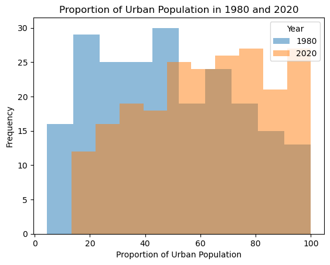

```python
# Write your answer here:
dataset = pd.read_csv("data/wdi_urban.csv")

years_unique = pd.unique(dataset["year"])
years_unique

for year in years_unique:
    subset = dataset[year == dataset["year"]]
    plt.hist(subset["prop_urbanpopulation"], alpha = 0.5)

plt.title("Proportion of Urban Population in 1980 and 2020")
plt.xlabel("Proportion of Urban Population")
plt.ylabel("Frequency")
plt.legend(labels = years_unique,
           title = "Year")
plt.show()
```